# Risk Factor Analysis

## Outcome Variable

**Outcome Variable:** whz

## Predictor Variables

**Intervention Variable:** vagbrth

**Adjustment Set:**

- arm
- sex
- W_mage
- meducyrs
- feducyrs
- hhwealth_quart
- W_mhtcm
- W_mwtkg
- W_mbmi
- single
- W_nrooms
- brthmon
- W_parity
- impfloor
- delta_W_mage
- delta_meducyrs
- delta_feducyrs
- delta_hhwealth_quart
- delta_W_mhtcm
- delta_W_mwtkg
- delta_W_mbmi
- delta_single
- delta_W_nrooms
- delta_brthmon
- delta_W_parity
- delta_impfloor

## Stratifying Variables

The analysis was stratified on these variable(s):

- agecat
- studyid
- country

## Data Summary

| agecat | studyid | country | vagbrth | n_cell | n | outcome_variable |
| --- | --- | --- | --- | --- | --- | --- |
| Birth | CMC-V-BCS-2002 | INDIA | 0 | 10 | 86 | whz |
| Birth | CMC-V-BCS-2002 | INDIA | 1 | 76 | 86 | whz |
| Birth | IRC | INDIA | 0 | 66 | 343 | whz |
| Birth | IRC | INDIA | 1 | 277 | 343 | whz |
| Birth | JiVitA-3 | BANGLADESH | 0 | 500 | 17985 | whz |
| Birth | JiVitA-3 | BANGLADESH | 1 | 17485 | 17985 | whz |
| Birth | JiVitA-4 | BANGLADESH | 0 | 71 | 2395 | whz |
| Birth | JiVitA-4 | BANGLADESH | 1 | 2324 | 2395 | whz |
| Birth | NIH-Crypto | BANGLADESH | 0 | 184 | 465 | whz |
| Birth | NIH-Crypto | BANGLADESH | 1 | 281 | 465 | whz |
| Birth | PROBIT | BELARUS | 0 | 1591 | 13817 | whz |
| Birth | PROBIT | BELARUS | 1 | 12226 | 13817 | whz |
| Birth | PROVIDE | BANGLADESH | 0 | 108 | 532 | whz |
| Birth | PROVIDE | BANGLADESH | 1 | 424 | 532 | whz |
| Birth | ZVITAMBO | ZIMBABWE | 0 | 1100 | 12814 | whz |
| Birth | ZVITAMBO | ZIMBABWE | 1 | 11714 | 12814 | whz |
| 6 months | CMC-V-BCS-2002 | INDIA | 0 | 25 | 368 | whz |
| 6 months | CMC-V-BCS-2002 | INDIA | 1 | 343 | 368 | whz |
| 6 months | IRC | INDIA | 0 | 68 | 408 | whz |
| 6 months | IRC | INDIA | 1 | 340 | 408 | whz |
| 6 months | JiVitA-3 | BANGLADESH | 0 | 1075 | 16705 | whz |
| 6 months | JiVitA-3 | BANGLADESH | 1 | 15630 | 16705 | whz |
| 6 months | JiVitA-4 | BANGLADESH | 0 | 337 | 4056 | whz |
| 6 months | JiVitA-4 | BANGLADESH | 1 | 3719 | 4056 | whz |
| 6 months | NIH-Crypto | BANGLADESH | 0 | 187 | 457 | whz |
| 6 months | NIH-Crypto | BANGLADESH | 1 | 270 | 457 | whz |
| 6 months | PROBIT | BELARUS | 0 | 1797 | 15757 | whz |
| 6 months | PROBIT | BELARUS | 1 | 13960 | 15757 | whz |
| 6 months | PROVIDE | BANGLADESH | 0 | 139 | 603 | whz |
| 6 months | PROVIDE | BANGLADESH | 1 | 464 | 603 | whz |
| 6 months | TanzaniaChild2 | TANZANIA, UNITED REPUBLIC OF | 0 | 189 | 2004 | whz |
| 6 months | TanzaniaChild2 | TANZANIA, UNITED REPUBLIC OF | 1 | 1815 | 2004 | whz |
| 6 months | ZVITAMBO | ZIMBABWE | 0 | 721 | 8437 | whz |
| 6 months | ZVITAMBO | ZIMBABWE | 1 | 7716 | 8437 | whz |
| 24 months | CMC-V-BCS-2002 | INDIA | 0 | 25 | 372 | whz |
| 24 months | CMC-V-BCS-2002 | INDIA | 1 | 347 | 372 | whz |
| 24 months | IRC | INDIA | 0 | 69 | 409 | whz |
| 24 months | IRC | INDIA | 1 | 340 | 409 | whz |
| 24 months | JiVitA-3 | BANGLADESH | 0 | 475 | 8555 | whz |
| 24 months | JiVitA-3 | BANGLADESH | 1 | 8080 | 8555 | whz |
| 24 months | JiVitA-4 | BANGLADESH | 0 | 323 | 4008 | whz |
| 24 months | JiVitA-4 | BANGLADESH | 1 | 3685 | 4008 | whz |
| 24 months | NIH-Crypto | BANGLADESH | 0 | 99 | 260 | whz |
| 24 months | NIH-Crypto | BANGLADESH | 1 | 161 | 260 | whz |
| 24 months | PROBIT | BELARUS | 0 | 463 | 3970 | whz |
| 24 months | PROBIT | BELARUS | 1 | 3507 | 3970 | whz |
| 24 months | PROVIDE | BANGLADESH | 0 | 137 | 579 | whz |
| 24 months | PROVIDE | BANGLADESH | 1 | 442 | 579 | whz |
| 24 months | TanzaniaChild2 | TANZANIA, UNITED REPUBLIC OF | 0 | 2 | 6 | whz |
| 24 months | TanzaniaChild2 | TANZANIA, UNITED REPUBLIC OF | 1 | 4 | 6 | whz |
| 24 months | ZVITAMBO | ZIMBABWE | 0 | 28 | 426 | whz |
| 24 months | ZVITAMBO | ZIMBABWE | 1 | 398 | 426 | whz |

The following strata were considered:

- agecat: 24 months, studyid: CMC-V-BCS-2002, country: INDIA
- agecat: 24 months, studyid: IRC, country: INDIA
- agecat: 24 months, studyid: JiVitA-3, country: BANGLADESH
- agecat: 24 months, studyid: JiVitA-4, country: BANGLADESH
- agecat: 24 months, studyid: NIH-Crypto, country: BANGLADESH
- agecat: 24 months, studyid: PROBIT, country: BELARUS
- agecat: 24 months, studyid: PROVIDE, country: BANGLADESH
- agecat: 24 months, studyid: TanzaniaChild2, country: TANZANIA, UNITED REPUBLIC OF
- agecat: 24 months, studyid: ZVITAMBO, country: ZIMBABWE
- agecat: 6 months, studyid: CMC-V-BCS-2002, country: INDIA
- agecat: 6 months, studyid: IRC, country: INDIA
- agecat: 6 months, studyid: JiVitA-3, country: BANGLADESH
- agecat: 6 months, studyid: JiVitA-4, country: BANGLADESH
- agecat: 6 months, studyid: NIH-Crypto, country: BANGLADESH
- agecat: 6 months, studyid: PROBIT, country: BELARUS
- agecat: 6 months, studyid: PROVIDE, country: BANGLADESH
- agecat: 6 months, studyid: TanzaniaChild2, country: TANZANIA, UNITED REPUBLIC OF
- agecat: 6 months, studyid: ZVITAMBO, country: ZIMBABWE
- agecat: Birth, studyid: CMC-V-BCS-2002, country: INDIA
- agecat: Birth, studyid: IRC, country: INDIA
- agecat: Birth, studyid: JiVitA-3, country: BANGLADESH
- agecat: Birth, studyid: JiVitA-4, country: BANGLADESH
- agecat: Birth, studyid: NIH-Crypto, country: BANGLADESH
- agecat: Birth, studyid: PROBIT, country: BELARUS
- agecat: Birth, studyid: PROVIDE, country: BANGLADESH
- agecat: Birth, studyid: ZVITAMBO, country: ZIMBABWE

### Dropped Strata

Some strata were dropped due to rare outcomes:

- agecat: 24 months, studyid: TanzaniaChild2, country: TANZANIA, UNITED REPUBLIC OF

## Methods Detail

We’re interested in the causal parameters $E[Y_a]$ for all values of $a \in \mathcal{A}$. These parameters represent the mean outcome if, possibly contrary to fact, we intervened to set all units to have $A=a$. Under the randomization and positivity assumptions, these are identified by the statistical parameters $\psi_a=E_W[E_{Y|A,W}(Y|A=a,W)]$. In addition, we’re interested in the mean of $Y$, $E[Y]$ under no intervention (the observed mean). We will estimate these parameters by using SuperLearner to fit the relevant likelihood factors – $E_{Y|A,W}(Y|A=a,W)$ and $p(A=a|W)$, and then updating our likelihood fit using a joint TMLE.

For unadjusted analyses ($W=\{\}$), initial likelihoods were estimated using Lrnr_glm to estimate the simple $E(Y|A)$ and Lrnr_mean to estimate $p(A)$. For adjusted analyses, a small library containing Lrnr_glmnet, Lrnr_xgboost, and Lrnr_mean was used.

Having estimated these parameters, we will then use the delta method to estimate relative risks and attributable risks relative to a prespecified baseline level of $A$.

# Results Detail

## Results Plots

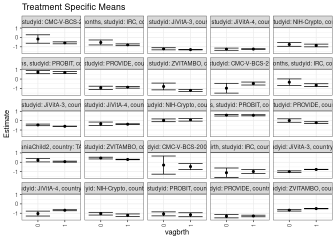

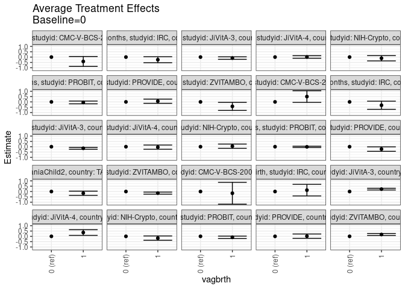

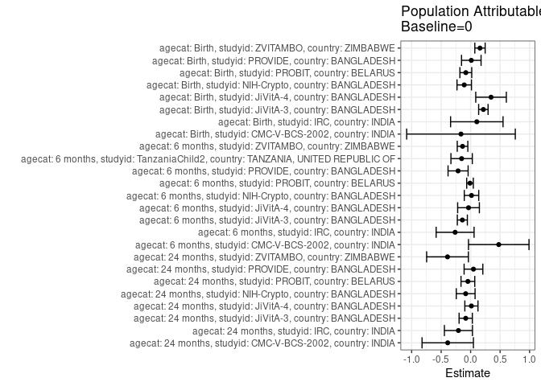

## Results Table

### Parameter: TSM

| agecat | studyid | country | intervention_level | baseline_level | estimate | ci_lower | ci_upper |
| --- | --- | --- | --- | --- | --- | --- | --- |
| Birth | CMC-V-BCS-2002 | INDIA | 0 | NA | -0.3013908 | -1.2713206 | 0.6685390 |
| Birth | CMC-V-BCS-2002 | INDIA | 1 | NA | -0.4621497 | -0.7846176 | -0.1396817 |
| Birth | IRC | INDIA | 0 | NA | -1.1158889 | -1.6199964 | -0.6117814 |
| Birth | IRC | INDIA | 1 | NA | -0.9864356 | -1.1880047 | -0.7848665 |
| Birth | JiVitA-3 | BANGLADESH | 0 | NA | -0.9939000 | -1.0750796 | -0.9127204 |
| Birth | JiVitA-3 | BANGLADESH | 1 | NA | -0.7693027 | -0.7886329 | -0.7499724 |
| Birth | JiVitA-4 | BANGLADESH | 0 | NA | -1.0356838 | -1.2978293 | -0.7735382 |
| Birth | JiVitA-4 | BANGLADESH | 1 | NA | -0.6786260 | -0.7321937 | -0.6250583 |
| Birth | NIH-Crypto | BANGLADESH | 0 | NA | -1.0467749 | -1.1930796 | -0.9004702 |
| Birth | NIH-Crypto | BANGLADESH | 1 | NA | -1.2141986 | -1.3536101 | -1.0747870 |
| Birth | PROBIT | BELARUS | 0 | NA | -1.0678258 | -1.2826223 | -0.8530293 |
| Birth | PROBIT | BELARUS | 1 | NA | -1.1607418 | -1.3733830 | -0.9481007 |
| Birth | PROVIDE | BANGLADESH | 0 | NA | -1.3100282 | -1.4938617 | -1.1261946 |
| Birth | PROVIDE | BANGLADESH | 1 | NA | -1.2927384 | -1.3792591 | -1.2062177 |
| Birth | ZVITAMBO | ZIMBABWE | 0 | NA | -0.6759225 | -0.7675297 | -0.5843153 |
| Birth | ZVITAMBO | ZIMBABWE | 1 | NA | -0.5028194 | -0.5299676 | -0.4756712 |
| 6 months | CMC-V-BCS-2002 | INDIA | 0 | NA | -0.9800353 | -1.5042462 | -0.4558245 |
| 6 months | CMC-V-BCS-2002 | INDIA | 1 | NA | -0.4795547 | -0.6374205 | -0.3216890 |
| 6 months | IRC | INDIA | 0 | NA | -0.3358875 | -0.6840498 | 0.0122748 |
| 6 months | IRC | INDIA | 1 | NA | -0.6506659 | -0.8003752 | -0.5009565 |
| 6 months | JiVitA-3 | BANGLADESH | 0 | NA | -0.4532280 | -0.5415091 | -0.3649468 |
| 6 months | JiVitA-3 | BANGLADESH | 1 | NA | -0.6021983 | -0.6219805 | -0.5824161 |
| 6 months | JiVitA-4 | BANGLADESH | 0 | NA | -0.3403750 | -0.5311770 | -0.1495730 |
| 6 months | JiVitA-4 | BANGLADESH | 1 | NA | -0.3793678 | -0.4244505 | -0.3342851 |
| 6 months | NIH-Crypto | BANGLADESH | 0 | NA | 0.0364589 | -0.1112755 | 0.1841933 |
| 6 months | NIH-Crypto | BANGLADESH | 1 | NA | 0.0842001 | -0.0499153 | 0.2183156 |
| 6 months | PROBIT | BELARUS | 0 | NA | 0.5843818 | 0.4959628 | 0.6728008 |
| 6 months | PROBIT | BELARUS | 1 | NA | 0.5729894 | 0.5133657 | 0.6326130 |
| 6 months | PROVIDE | BANGLADESH | 0 | NA | 0.0135818 | -0.1707292 | 0.1978929 |
| 6 months | PROVIDE | BANGLADESH | 1 | NA | -0.2091141 | -0.3039644 | -0.1142637 |
| 6 months | TanzaniaChild2 | TANZANIA, UNITED REPUBLIC OF | 0 | NA | 0.2296009 | 0.0390236 | 0.4201782 |
| 6 months | TanzaniaChild2 | TANZANIA, UNITED REPUBLIC OF | 1 | NA | 0.0667825 | 0.0117002 | 0.1218647 |
| 6 months | ZVITAMBO | ZIMBABWE | 0 | NA | 0.4484903 | 0.3549502 | 0.5420305 |
| 6 months | ZVITAMBO | ZIMBABWE | 1 | NA | 0.2987050 | 0.2717879 | 0.3256220 |
| 24 months | CMC-V-BCS-2002 | INDIA | 0 | NA | -0.1687985 | -0.6187871 | 0.2811900 |
| 24 months | CMC-V-BCS-2002 | INDIA | 1 | NA | -0.5791731 | -0.6836748 | -0.4746713 |
| 24 months | IRC | INDIA | 0 | NA | -0.5390967 | -0.8052057 | -0.2729877 |
| 24 months | IRC | INDIA | 1 | NA | -0.7881085 | -0.8839625 | -0.6922546 |
| 24 months | JiVitA-3 | BANGLADESH | 0 | NA | -1.2153990 | -1.3288052 | -1.1019927 |
| 24 months | JiVitA-3 | BANGLADESH | 1 | NA | -1.3067413 | -1.3308831 | -1.2825995 |
| 24 months | JiVitA-4 | BANGLADESH | 0 | NA | -1.2567136 | -1.3736514 | -1.1397758 |
| 24 months | JiVitA-4 | BANGLADESH | 1 | NA | -1.2446067 | -1.2800970 | -1.2091163 |
| 24 months | NIH-Crypto | BANGLADESH | 0 | NA | -0.7504229 | -0.9487183 | -0.5521276 |
| 24 months | NIH-Crypto | BANGLADESH | 1 | NA | -0.8609187 | -1.0077867 | -0.7140507 |
| 24 months | PROBIT | BELARUS | 0 | NA | 0.7445112 | 0.5711284 | 0.9178940 |
| 24 months | PROBIT | BELARUS | 1 | NA | 0.6935535 | 0.5814465 | 0.8056605 |
| 24 months | PROVIDE | BANGLADESH | 0 | NA | -0.9412790 | -1.1174090 | -0.7651490 |
| 24 months | PROVIDE | BANGLADESH | 1 | NA | -0.8771248 | -0.9716814 | -0.7825682 |
| 24 months | ZVITAMBO | ZIMBABWE | 0 | NA | -0.7945118 | -1.1570402 | -0.4319834 |
| 24 months | ZVITAMBO | ZIMBABWE | 1 | NA | -1.2154312 | -1.3194029 | -1.1114595 |

### Parameter: E(Y)

| agecat | studyid | country | intervention_level | baseline_level | estimate | ci_lower | ci_upper |
| --- | --- | --- | --- | --- | --- | --- | --- |
| Birth | CMC-V-BCS-2002 | INDIA | NA | NA | -0.4648256 | -0.7643210 | -0.1653302 |
| Birth | IRC | INDIA | NA | NA | -1.0105831 | -1.1973019 | -0.8238643 |
| Birth | JiVitA-3 | BANGLADESH | NA | NA | -0.7774729 | -0.7964631 | -0.7584827 |
| Birth | JiVitA-4 | BANGLADESH | NA | NA | -0.6890188 | -0.7414800 | -0.6365575 |
| Birth | NIH-Crypto | BANGLADESH | NA | NA | -1.1549785 | -1.2577390 | -1.0522180 |
| Birth | PROBIT | BELARUS | NA | NA | -1.1491782 | -1.3593933 | -0.9389630 |
| Birth | PROVIDE | BANGLADESH | NA | NA | -1.2984586 | -1.3752758 | -1.2216415 |
| Birth | ZVITAMBO | ZIMBABWE | NA | NA | -0.5168886 | -0.5428625 | -0.4909146 |
| 6 months | CMC-V-BCS-2002 | INDIA | NA | NA | -0.5026766 | -0.6536848 | -0.3516685 |
| 6 months | IRC | INDIA | NA | NA | -0.5989297 | -0.7344491 | -0.4634104 |
| 6 months | JiVitA-3 | BANGLADESH | NA | NA | -0.5935070 | -0.6130727 | -0.5739413 |
| 6 months | JiVitA-4 | BANGLADESH | NA | NA | -0.3758037 | -0.4184544 | -0.3331531 |
| 6 months | NIH-Crypto | BANGLADESH | NA | NA | 0.0515536 | -0.0469240 | 0.1500313 |
| 6 months | PROBIT | BELARUS | NA | NA | 0.5741099 | 0.5141290 | 0.6340908 |
| 6 months | PROVIDE | BANGLADESH | NA | NA | -0.1990907 | -0.2817968 | -0.1163845 |
| 6 months | TanzaniaChild2 | TANZANIA, UNITED REPUBLIC OF | NA | NA | 0.0769382 | 0.0241090 | 0.1297674 |
| 6 months | ZVITAMBO | ZIMBABWE | NA | NA | 0.3116179 | 0.2858347 | 0.3374010 |
| 24 months | CMC-V-BCS-2002 | INDIA | NA | NA | -0.5571505 | -0.6585247 | -0.4557763 |
| 24 months | IRC | INDIA | NA | NA | -0.7458150 | -0.8368180 | -0.6548120 |
| 24 months | JiVitA-3 | BANGLADESH | NA | NA | -1.2983928 | -1.3216893 | -1.2750962 |
| 24 months | JiVitA-4 | BANGLADESH | NA | NA | -1.2433658 | -1.2774681 | -1.2092634 |
| 24 months | NIH-Crypto | BANGLADESH | NA | NA | -0.8343077 | -0.9482310 | -0.7203844 |
| 24 months | PROBIT | BELARUS | NA | NA | 0.6981406 | 0.5843775 | 0.8119038 |
| 24 months | PROVIDE | BANGLADESH | NA | NA | -0.8928670 | -0.9755153 | -0.8102187 |
| 24 months | ZVITAMBO | ZIMBABWE | NA | NA | -1.1864319 | -1.2865891 | -1.0862748 |

### Parameter: ATE

| agecat | studyid | country | intervention_level | baseline_level | estimate | ci_lower | ci_upper |
| --- | --- | --- | --- | --- | --- | --- | --- |
| Birth | CMC-V-BCS-2002 | INDIA | 0 | 0 | 0.0000000 | 0.0000000 | 0.0000000 |
| Birth | CMC-V-BCS-2002 | INDIA | 1 | 0 | -0.1607588 | -1.1849643 | 0.8634466 |
| Birth | IRC | INDIA | 0 | 0 | 0.0000000 | 0.0000000 | 0.0000000 |
| Birth | IRC | INDIA | 1 | 0 | 0.1294533 | -0.4143662 | 0.6732728 |
| Birth | JiVitA-3 | BANGLADESH | 0 | 0 | 0.0000000 | 0.0000000 | 0.0000000 |
| Birth | JiVitA-3 | BANGLADESH | 1 | 0 | 0.2245973 | 0.1418706 | 0.3073241 |
| Birth | JiVitA-4 | BANGLADESH | 0 | 0 | 0.0000000 | 0.0000000 | 0.0000000 |
| Birth | JiVitA-4 | BANGLADESH | 1 | 0 | 0.3570578 | 0.0894584 | 0.6246571 |
| Birth | NIH-Crypto | BANGLADESH | 0 | 0 | 0.0000000 | 0.0000000 | 0.0000000 |
| Birth | NIH-Crypto | BANGLADESH | 1 | 0 | -0.1674237 | -0.3701283 | 0.0352809 |
| Birth | PROBIT | BELARUS | 0 | 0 | 0.0000000 | 0.0000000 | 0.0000000 |
| Birth | PROBIT | BELARUS | 1 | 0 | -0.0929160 | -0.2066747 | 0.0208426 |
| Birth | PROVIDE | BANGLADESH | 0 | 0 | 0.0000000 | 0.0000000 | 0.0000000 |
| Birth | PROVIDE | BANGLADESH | 1 | 0 | 0.0172897 | -0.1856732 | 0.2202527 |
| Birth | ZVITAMBO | ZIMBABWE | 0 | 0 | 0.0000000 | 0.0000000 | 0.0000000 |
| Birth | ZVITAMBO | ZIMBABWE | 1 | 0 | 0.1731031 | 0.0777068 | 0.2684993 |
| 6 months | CMC-V-BCS-2002 | INDIA | 0 | 0 | 0.0000000 | 0.0000000 | 0.0000000 |
| 6 months | CMC-V-BCS-2002 | INDIA | 1 | 0 | 0.5004806 | -0.0460168 | 1.0469779 |
| 6 months | IRC | INDIA | 0 | 0 | 0.0000000 | 0.0000000 | 0.0000000 |
| 6 months | IRC | INDIA | 1 | 0 | -0.3147784 | -0.6977712 | 0.0682145 |
| 6 months | JiVitA-3 | BANGLADESH | 0 | 0 | 0.0000000 | 0.0000000 | 0.0000000 |
| 6 months | JiVitA-3 | BANGLADESH | 1 | 0 | -0.1489703 | -0.2377019 | -0.0602388 |
| 6 months | JiVitA-4 | BANGLADESH | 0 | 0 | 0.0000000 | 0.0000000 | 0.0000000 |
| 6 months | JiVitA-4 | BANGLADESH | 1 | 0 | -0.0389928 | -0.2349734 | 0.1569879 |
| 6 months | NIH-Crypto | BANGLADESH | 0 | 0 | 0.0000000 | 0.0000000 | 0.0000000 |
| 6 months | NIH-Crypto | BANGLADESH | 1 | 0 | 0.0477412 | -0.1520242 | 0.2475067 |
| 6 months | PROBIT | BELARUS | 0 | 0 | 0.0000000 | 0.0000000 | 0.0000000 |
| 6 months | PROBIT | BELARUS | 1 | 0 | -0.0113925 | -0.0743749 | 0.0515900 |
| 6 months | PROVIDE | BANGLADESH | 0 | 0 | 0.0000000 | 0.0000000 | 0.0000000 |
| 6 months | PROVIDE | BANGLADESH | 1 | 0 | -0.2226959 | -0.4319113 | -0.0134805 |
| 6 months | TanzaniaChild2 | TANZANIA, UNITED REPUBLIC OF | 0 | 0 | 0.0000000 | 0.0000000 | 0.0000000 |
| 6 months | TanzaniaChild2 | TANZANIA, UNITED REPUBLIC OF | 1 | 0 | -0.1628184 | -0.3613625 | 0.0357257 |
| 6 months | ZVITAMBO | ZIMBABWE | 0 | 0 | 0.0000000 | 0.0000000 | 0.0000000 |
| 6 months | ZVITAMBO | ZIMBABWE | 1 | 0 | -0.1497854 | -0.2469746 | -0.0525961 |
| 24 months | CMC-V-BCS-2002 | INDIA | 0 | 0 | 0.0000000 | 0.0000000 | 0.0000000 |
| 24 months | CMC-V-BCS-2002 | INDIA | 1 | 0 | -0.4103745 | -0.8733880 | 0.0526390 |
| 24 months | IRC | INDIA | 0 | 0 | 0.0000000 | 0.0000000 | 0.0000000 |
| 24 months | IRC | INDIA | 1 | 0 | -0.2490118 | -0.5316663 | 0.0336426 |
| 24 months | JiVitA-3 | BANGLADESH | 0 | 0 | 0.0000000 | 0.0000000 | 0.0000000 |
| 24 months | JiVitA-3 | BANGLADESH | 1 | 0 | -0.0913424 | -0.2079404 | 0.0252557 |
| 24 months | JiVitA-4 | BANGLADESH | 0 | 0 | 0.0000000 | 0.0000000 | 0.0000000 |
| 24 months | JiVitA-4 | BANGLADESH | 1 | 0 | 0.0121069 | -0.1080931 | 0.1323069 |
| 24 months | NIH-Crypto | BANGLADESH | 0 | 0 | 0.0000000 | 0.0000000 | 0.0000000 |
| 24 months | NIH-Crypto | BANGLADESH | 1 | 0 | -0.1104958 | -0.3585079 | 0.1375164 |
| 24 months | PROBIT | BELARUS | 0 | 0 | 0.0000000 | 0.0000000 | 0.0000000 |
| 24 months | PROBIT | BELARUS | 1 | 0 | -0.0509576 | -0.1814216 | 0.0795063 |
| 24 months | PROVIDE | BANGLADESH | 0 | 0 | 0.0000000 | 0.0000000 | 0.0000000 |
| 24 months | PROVIDE | BANGLADESH | 1 | 0 | 0.0641542 | -0.1337987 | 0.2621071 |
| 24 months | ZVITAMBO | ZIMBABWE | 0 | 0 | 0.0000000 | 0.0000000 | 0.0000000 |
| 24 months | ZVITAMBO | ZIMBABWE | 1 | 0 | -0.4209194 | -0.7985088 | -0.0433300 |

### Parameter: PAR

| agecat | studyid | country | intervention_level | baseline_level | estimate | ci_lower | ci_upper |
| --- | --- | --- | --- | --- | --- | --- | --- |
| Birth | CMC-V-BCS-2002 | INDIA | 0 | NA | -0.1634347 | -1.0850121 | 0.7581426 |
| Birth | IRC | INDIA | 0 | NA | 0.1053058 | -0.3396986 | 0.5503102 |
| Birth | JiVitA-3 | BANGLADESH | 0 | NA | 0.2164271 | 0.1363589 | 0.2964953 |
| Birth | JiVitA-4 | BANGLADESH | 0 | NA | 0.3466650 | 0.0872059 | 0.6061241 |
| Birth | NIH-Crypto | BANGLADESH | 0 | NA | -0.1082036 | -0.2307973 | 0.0143901 |
| Birth | PROBIT | BELARUS | 0 | NA | -0.0813524 | -0.1816079 | 0.0189032 |
| Birth | PROVIDE | BANGLADESH | 0 | NA | 0.0115695 | -0.1541782 | 0.1773172 |
| Birth | ZVITAMBO | ZIMBABWE | 0 | NA | 0.1590339 | 0.0712954 | 0.2467725 |
| 6 months | CMC-V-BCS-2002 | INDIA | 0 | NA | 0.4773587 | -0.0358849 | 0.9906023 |
| 6 months | IRC | INDIA | 0 | NA | -0.2630422 | -0.5849263 | 0.0588419 |
| 6 months | JiVitA-3 | BANGLADESH | 0 | NA | -0.1402791 | -0.2253715 | -0.0551867 |
| 6 months | JiVitA-4 | BANGLADESH | 0 | NA | -0.0354287 | -0.2196456 | 0.1487882 |
| 6 months | NIH-Crypto | BANGLADESH | 0 | NA | 0.0150947 | -0.1075474 | 0.1377368 |
| 6 months | PROBIT | BELARUS | 0 | NA | -0.0102719 | -0.0663965 | 0.0458527 |
| 6 months | PROVIDE | BANGLADESH | 0 | NA | -0.2126725 | -0.3829828 | -0.0423622 |
| 6 months | TanzaniaChild2 | TANZANIA, UNITED REPUBLIC OF | 0 | NA | -0.1526627 | -0.3339389 | 0.0286136 |
| 6 months | ZVITAMBO | ZIMBABWE | 0 | NA | -0.1368724 | -0.2264684 | -0.0472765 |
| 24 months | CMC-V-BCS-2002 | INDIA | 0 | NA | -0.3883520 | -0.8240605 | 0.0473565 |
| 24 months | IRC | INDIA | 0 | NA | -0.2067183 | -0.4446733 | 0.0312367 |
| 24 months | JiVitA-3 | BANGLADESH | 0 | NA | -0.0829938 | -0.1953727 | 0.0293851 |
| 24 months | JiVitA-4 | BANGLADESH | 0 | NA | 0.0133478 | -0.0981341 | 0.1248297 |
| 24 months | NIH-Crypto | BANGLADESH | 0 | NA | -0.0838847 | -0.2432644 | 0.0754949 |
| 24 months | PROBIT | BELARUS | 0 | NA | -0.0463705 | -0.1630518 | 0.0703107 |
| 24 months | PROVIDE | BANGLADESH | 0 | NA | 0.0484120 | -0.1104904 | 0.2073144 |
| 24 months | ZVITAMBO | ZIMBABWE | 0 | NA | -0.3919201 | -0.7460497 | -0.0377904 |